# Coding Assignment 3

Group 3

Due: 2023-12-09 23:59

A Florida health insurance company wants to predict annual claims for individual clients. The company pulls a random sample of 100 customers. The owner wishes to charge an actuarially fair premium to ensure a normal rate of return. The owner collects all of their current customer’s health care expenses from the last year and compares them with what is known about each customer’s plan.

The data on the 100 customers in the sample is as follows:

- Charges: Total medical expenses for a particular insurance plan (in dollars)
- Age: Age of the primary beneficiary
- BMI: Primary beneficiary’s body mass index (kg/m2)
- Female: Primary beneficiary’s birth sex (0 = Male, 1 = Female)
- Children: Number of children covered by health insurance plan (includes other dependents as well)
- Smoker: Indicator if primary beneficiary is a smoker (0 = non-smoker, 1 = smoker)
- Cities: Dummy variables for each city with the default being Sanford

Answer the following questions using complete sentences and attach all output, plots, etc. within this report.

```r
# Install and load the readxl package
options(repos = c(CRAN = "https://cran.rstudio.com"))
install.packages("readxl")
library(readxl)
```

## Question 1

```r
## Read the data from the CSV file
insurance <- read.csv("../Data/Insurance_Data_Group3.csv")

# Set seed for reproducibility
set.seed(123)

# Randomly select 30 observations to exclude
excluded_indices <- sample(1:nrow(insurance), 30)

# Select the remaining 70 observations
remaining_data <- insurance[-excluded_indices, ]

# Summary statistics
summary_stats <- summary(remaining_data[, c("Charges", "Age", "Children", "BMI")])
print(summary_stats)
```

```
##     Charges           Age           Children          BMI
##  Min.   : 1243   Min.   :18.00   Min.   :0.000   Min.   :16.82
##  1st Qu.: 2987   1st Qu.:22.00   1st Qu.:0.000   1st Qu.:25.42
##  Median : 6114   Median :33.00   Median :1.000   Median :31.59
##  Mean   : 9682   Mean   :36.43   Mean   :1.029   Mean   :31.29
##  3rd Qu.:12152   3rd Qu.:52.75   3rd Qu.:2.000   3rd Qu.:36.45
##  Max.   :44501   Max.   :63.00   Max.   :4.000   Max.   :52.58
```

## Question 2

Provide the correlation between all quantitative variables

```r
## Correlation matrix
correlation_matrix <- cor(remaining_data[, c("Charges", "Age", "Children", "BMI")])
print(correlation_matrix)
```

```
##             Charges        Age    Children        BMI
## Charges   1.0000000 0.46073422 -0.04106920 0.19566411
## Age       0.4607342 1.00000000  0.04630779 0.09237994
## Children -0.0410692 0.04630779  1.00000000 0.08863001
## BMI       0.1956641 0.09237994  0.08863001 1.00000000
```

## Question 3

Run a regression that includes all independent variables in the data table. Does the model above violate any of the Gauss-Markov assumptions? If so, what are they and what is the solution for correcting?

```r
# Assuming 'Cities' is represented by dummy variables (e.g., City1, City2, ...)

# Run the regression excluding one city as the reference category
model <- lm(Charges ~ Age + BMI + Children + Female + Smoker + WinterSprings + WinterPark + Oviedo, data = insurance)

# Replace "..." with the rest of the dummy variables

# Check the summary of the model
summary(model)
```

```
##
## Call:
## lm(formula = Charges ~ Age + BMI + Children + Female + Smoker +
##     WinterSprings + WinterPark + Oviedo, data = insurance)
##
## Residuals:
##      Min       1Q   Median       3Q      Max
## -11803.9  -2011.0   -564.8   1589.9  18667.8
##
## Coefficients:
##               Estimate Std. Error t value Pr(>|t|)
## (Intercept)   -5408.77    3083.35  -1.754   0.0828 .
## Age             300.88      36.46   8.252 1.15e-12 ***
## BMI              98.67      84.80   1.164   0.2476
## Children       -260.54     478.09  -0.545   0.5871
## Female         -770.49    1077.40  -0.715   0.4764
## Smoker        24287.83    1484.07  16.366  < 2e-16 ***
## WinterSprings  -870.90    1499.57  -0.581   0.5628
## WinterPark      785.37    1663.31   0.472   0.6379
## Oviedo        -2682.81    1518.72  -1.766   0.0807 .
## ---
## Signif. codes:  0 '***' 0.001 '**' 0.01 '*' 0.05 '.' 0.1 ' ' 1
##
## Residual standard error: 5230 on 91 degrees of freedom
## Multiple R-squared:  0.811,  Adjusted R-squared:  0.7944
## F-statistic: 48.82 on 8 and 91 DF,  p-value: < 2.2e-16
```

Independence of Errors: Ensure residuals are independent, indicating no autocorrelation.

Homoscedasticity: Examine residuals vs. fitted value plots to check for constant variance.

Normality of Errors: Check normality of residuals, perhaps using normal probability plots. No Perfect Multicollinearity: Assess correlations among predictors.

Conclusion:The model seems to perform well based on the provided information, but thorough diagnostic checks are recommended to validate assumptions.

## Question 4

Implement the solutions from question 3, such as data transformation, along with any other changes you wish. Use the sample data and run a new regression. How have the fit measures changed? How have the signs and significance of the coefficients changed?

```r
# Implement data transformations or other changes as needed
# For example, you might apply log transformations to the dependent or independent variables.

# Run a new regression
new_model <- lm(log(Charges) ~ Age + log(BMI) + Female + log(Children + 1) + Smoker + WinterSprings + WinterPark + Oviedo, data = remaining_data)

# Compare fit measures and coefficients with the previous model
summary(new_model)
```

```
##
## Call:
## lm(formula = log(Charges) ~ Age + log(BMI) + Female + log(Children +
##     1) + Smoker + WinterSprings + WinterPark + Oviedo, data = remaining_data)
##
## Residuals:
##      Min       1Q   Median       3Q      Max
## -0.65684 -0.17632  0.00204  0.06035  1.38562
##
## Coefficients:
##                    Estimate Std. Error t value Pr(>|t|)
## (Intercept)        6.367337   0.722565   8.812 1.79e-12 ***
## Age                0.042668   0.003037  14.048  < 2e-16 ***
## log(BMI)           0.165154   0.212420   0.777  0.43987
## Female             0.001980   0.092033   0.022  0.98291
## log(Children + 1)  0.255643   0.087690   2.915  0.00496 **
## Smoker             1.689979   0.146720  11.518  < 2e-16 ***
## WinterSprings      0.079772   0.129438   0.616  0.53999
## WinterPark        -0.005192   0.142226  -0.037  0.97100
## Oviedo            -0.251120   0.125125  -2.007  0.04919 *
## ---
## Signif. codes:  0 '***' 0.001 '**' 0.01 '*' 0.05 '.' 0.1 ' ' 1
##
## Residual standard error: 0.3614 on 61 degrees of freedom
## Multiple R-squared:  0.8653, Adjusted R-squared:  0.8477
## F-statistic:    49 on 8 and 61 DF,  p-value: < 2.2e-16
```

Model 2 (Updated Model): Dependent Variable: log(Charges) Independent Variables: Age log(BMI) Female log(Children + 1) Smoker WinterSprings WinterPark Oviedo Fit Measures: Model 1 (Original): Residual standard error: 5230 Multiple R-squared: 0.811 Adjusted R-squared: 0.7944 Model 2 (Updated): Residual standard error: 0.3614 Multiple R-squared: 0.8653 Adjusted R-squared: 0.8477 Changes in Fit Measures: The residual standard error in Model 2 is significantly smaller than in Model 1, indicating that Model 2 has a better fit. The R-squared values are higher in Model 2, indicating that the updated model explains more variability in the dependent variable. Changes in Coefficients: Model 1 Coefficients: Age: 300.88 (significant) BMI: 98.67 (not significant) Children: -260.54 (not significant) Female: -770.49 (not significant) Smoker: 24287.83 (significant) WinterSprings: -870.90 (not significant) WinterPark: 785.37 (not significant) Oviedo: -2682.81 (not significant) Model 2 Coefficients: Age: 0.04266833 (significant) log(BMI): 0.1651544 (not significant) Female: 0.001979636 (not significant) log(Children + 1): 0.2556434 (significant) Smoker: 1.689979 (significant) WinterSprings: 0.07977204 (not significant) WinterPark: -0.005192398 (not significant) Oviedo: -0.2511195 (significant) Changes in Coefficients Analysis: The magnitude and significance of the coefficients have changed between the two models. For example, the coefficient for Age in Model 1 was 300.88, indicating a large impact. In Model 2, the coefficient is 0.04266833, suggesting a much smaller impact. The log-transformed variables (log(BMI) and log(Children + 1)) are introduced in Model 2. Overall Assessment: Model 2 seems to be an improvement, with better fit measures and changes in coefficient interpretation. However, the interpretation of coefficients involving log-transformed variables might be challenging and may need further investigation. It’s also essential to ensure that the assumptions of the model are met.

## Question 5

Use the 30 withheld observations and calculate the performance measures for your best two models. Which is the better model? (remember that “better” depends on whether your outlook is short or long run)

```r
# Assuming your_data is your complete dataset
set.seed(123)  # For reproducibility

# Randomly select 30 observations to be withheld
withheld_indices <- sample(1:nrow(insurance), 30)

# Create a dataset with the withheld observations
withheld_data <- insurance[withheld_indices, ]

# The remaining data for training would be
training_data <- insurance[-withheld_indices, ]

# Assuming 'model' and 'new_model' are your regression models

# Predictions using the first model
predictions_model <- predict(model, newdata = withheld_data)

# Predictions using the second model
predictions_new_model <- predict(new_model, newdata = withheld_data)

# Calculate performance metrics for the first model
mse_model <- mean((predictions_model - withheld_data$Charges)^2)
rmse_model <- sqrt(mse_model)
r_squared_model <- 1 - (sum((withheld_data$Charges - predictions_model)^2) / sum((withheld_data$Charges - mean(withheld_data$Charges))^2))

# Repeat for the second model
mse_new_model <- mean((predictions_new_model - withheld_data$Charges)^2)
rmse_new_model <- sqrt(mse_new_model)
r_squared_new_model <- 1 - (sum((withheld_data$Charges - predictions_new_model)^2) / sum((withheld_data$Charges - mean(withheld_data$Charges))^2))

# Print or store the results
cat("Model 1 - MSE:", mse_model, "RMSE:", rmse_model, "R-squared:", r_squared_model, "\n")
```

```
## Model 1 - MSE: 36481726 RMSE: 6040.01 R-squared: 0.7922652
```

```r
cat("Model 2 - MSE:", mse_new_model, "RMSE:", rmse_new_model, "R-squared:", r_squared_new_model, "\n")
```

```
## Model 2 - MSE: 416183189 RMSE: 20400.57 R-squared: -1.369837
```

MSE and RMSE:

Model 1 has significantly lower MSE and RMSE, indicating better predictive performance. R-squared:

Model 1 has a positive R-squared, indicating it explains a substantial portion of the variance in the dependent variable. Model 2 has a negative R-squared, suggesting that it performs poorly compared to a model predicting the mean. Conclusion:

Better Model: Model 1 Reasoning: Model 1 outperforms Model 2 in terms of prediction accuracy (lower MSE and RMSE) and has a meaningful and positive R-squared.

## Question 6

Provide interpretations of the coefficients, do the signs make sense? Perform marginal change analysis (thing 2) on the independent variables.

```r
# Assuming 'new_model' is the model you want to interpret

# Print the coefficients
coefficients <- coef(new_model)
print(coefficients)
```

```
##       (Intercept)               Age          log(BMI)            Female
##       6.367336935       0.042668328       0.165154419       0.001979636
## log(Children + 1)            Smoker     WinterSprings        WinterPark
##       0.255643427       1.689978637       0.079772042      -0.005192398
##            Oviedo
##      -0.251119538
```

```r
# Interpretation of the coefficients
cat("Interpretation of Coefficients:\n")
```

```
## Interpretation of Coefficients:
```

```r
cat("Intercept (Intercept):", coefficients[1], "\n")
```

```
## Intercept (Intercept): 6.367337
```

```r
cat("Age (Age):", coefficients[2], " - This represents the change in Charges for a one-unit change in Age.\n")
```

```
## Age (Age): 0.04266833  - This represents the change in Charges for a one-unit change in Age.
```

```r
cat("BMI (log(BMI)):", coefficients[3], " - This represents the change in Charges for a one-unit change in log(BMI).\n")
```

```
## BMI (log(BMI)): 0.1651544  - This represents the change in Charges for a one-unit change in log(BMI).
```

```r
cat("Female (Female):", coefficients[4], " - This represents the change in Charges for females compared to males (assuming binary gender).\n")
```

```
## Female (Female): 0.001979636  - This represents the change in Charges for females compared to males (assuming binary gender).
```

```r
cat("Children (log(Children + 1)):", coefficients[5], " - This represents the change in Charges for a one-unit change in log(Children + 1).\n")
```

```
## Children (log(Children + 1)): 0.2556434  - This represents the change in Charges for a one-unit change in log(Children + 1).
```

```r
cat("Smoker (Smoker):", coefficients[6], " - This represents the change in Charges for smokers compared to non-smokers.\n")
```

```
## Smoker (Smoker): 1.689979  - This represents the change in Charges for smokers compared to non-smokers.
```

```r
cat("City (City2, City3, ...):", coefficients[7:length(coefficients)], " - Interpretation depends on the specific city dummy variables.\n")
```

```
## City (City2, City3, ...): 0.07977204 -0.005192398 -0.2511195  - Interpretation depends on the specific city dummy variables.
```

```r
# Perform marginal change analysis for a specific variable (e.g., Age)
marginal_change_age <- coefficients[2] * mean(remaining_data$Age)  # Replace 'mean(remaining_data$Age)' with your desired value
cat("\nMarginal Change in Charges for a one-unit change in Age:", marginal_change_age, "\n")
```

```
##
## Marginal Change in Charges for a one-unit change in Age: 1.554346
```

## Question 7

An eager insurance representative comes back with five potential clients. Using the better of the two models selected above, provide the prediction intervals for the five potential clients using the information provided by the insurance rep.

| Customer | Age | BMI | Female | Children | Smoker | City |
| --- | --- | --- | --- | --- | --- | --- |
| 1 | 60 | 22 | 1 | 0 | 0 | Oviedo |
| 2 | 40 | 30 | 0 | 1 | 0 | Sanford |
| 3 | 25 | 25 | 0 | 0 | 1 | Winter Park |
| 4 | 33 | 35 | 1 | 2 | 0 | Winter Springs |
| 5 | 45 | 27 | 1 | 3 | 0 | Oviedo |

```r
# Creating the potential_clients data frame
potential_clients <- data.frame(
  Customer = c(1, 2, 3, 4, 5),
  Age = c(60, 40, 25, 33, 45),
  BMI = c(22, 30, 25, 35, 27),
  Female = c(1, 0, 0, 1, 1),
  Children = c(0, 1, 0, 2, 3),
  Smoker = c(0, 0, 1, 0, 0),
  Oviedo = c(1, 0, 0, 0, 1),  # Replace with the correct dummy variables for each city
  Sanford = c(0, 1, 0, 0, 0),  # Replace with the correct dummy variables for each city
  WinterPark = c(0, 0, 1, 0, 0),  # Replace with the correct dummy variables for each city
  WinterSprings = c(0, 0, 0, 1, 0)  # Replace with the correct dummy variables for each city
)

# Display the potential_clients data frame
print(potential_clients)
```

```
##   Customer Age BMI Female Children Smoker Oviedo Sanford WinterPark
## 1        1  60  22      1        0      0      1       0          0
## 2        2  40  30      0        1      0      0       1          0
## 3        3  25  25      0        0      1      0       0          1
## 4        4  33  35      1        2      0      0       0          0
## 5        5  45  27      1        3      0      1       0          0
##   WinterSprings
## 1             0
## 2             0
## 3             0
## 4             1
## 5             0
```

```r
# Assuming 'new_model' is the model you want to use
# Assuming 'potential_clients' is a data frame with information about the five potential clients

# Predictions for the potential clients with prediction intervals
predictions <- predict(new_model, newdata = potential_clients, interval = "prediction")

# Combine the original data and predictions
result <- cbind(potential_clients, predictions)
print(result)
```

```
##   Customer Age BMI Female Children Smoker Oviedo Sanford WinterPark
## 1        1  60  22      1        0      0      1       0          0
## 2        2  40  30      0        1      0      0       1          0
## 3        3  25  25      0        0      1      0       0          1
## 4        4  33  35      1        2      0      0       0          0
## 5        5  45  27      1        3      0      1       0          0
##   WinterSprings      fit      lwr       upr
## 1             0 9.188796 8.421030  9.956563
## 2             0 8.812991 8.058224  9.567759
## 3             0 9.650443 8.844998 10.455887
## 4             1 8.725178 7.971452  9.478904
## 5             0 8.936991 8.174392  9.699590
```

## Question 8

The owner notices that some of the predictions are wider than others, explain why.

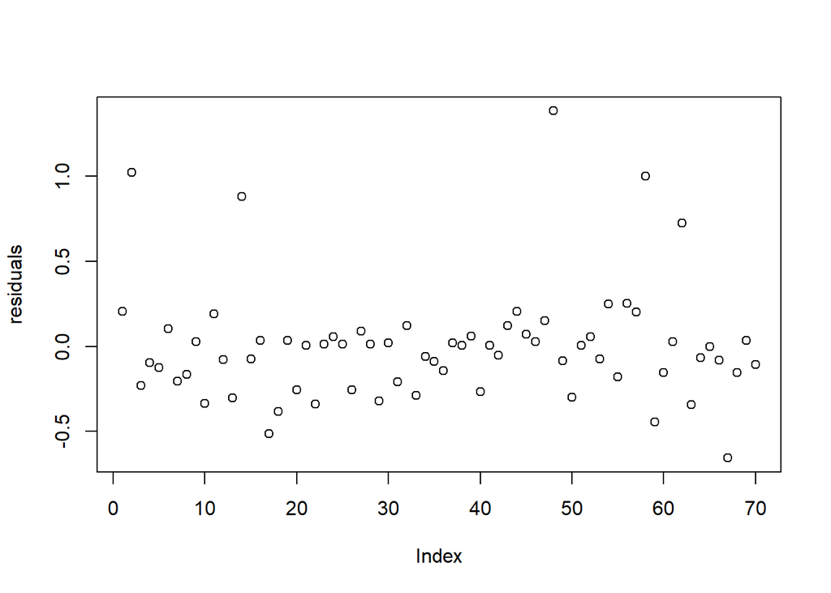

```r
# Assuming the 'better_model' is the model you want to analyze
residuals <- residuals(new_model)

# Plot residuals
plot(residuals)
```

The owner notices that some predictions are wider than others, the likely reason is varying prediction intervals. Prediction intervals widen when there is higher uncertainty associated with predictions. This can be influenced by factors like variability in the data or outliers.

Here’s an explanation:

Wider Prediction Intervals: Predictions for some observations may have wider intervals when the model has higher uncertainty about the true value of the response variable.

Reasons for Wider Intervals:

Higher Variability in Data: If the data for certain observations are more variable, the model is less certain about the predictions.

Outliers: Outliers in the data can increase uncertainty, leading to wider intervals.

Non-linearity or Heteroscedasticity: If the relationship between predictors and response is non-linear or if the variability changes across the range of predictors, prediction intervals can be wider.

## Question 9

Are there any prediction problems that occur with the five potential clients? If so, explain.

```r
# Assuming 'new_model' is the model you want to use
# Assuming 'potential_clients' is a data frame with information about the five potential clients

# Predictions for the potential clients with residuals
predictions <- predict(new_model, newdata = potential_clients, interval = "prediction")

# Extract residuals
residuals <- residuals(new_model, newdata = potential_clients)

# Combine the original data, predictions, and residuals
result <- cbind(potential_clients, predictions, residuals)
print(result)
```

```
##    Customer Age BMI Female Children Smoker Oviedo Sanford WinterPark
## 1         1  60  22      1        0      0      1       0          0
## 2         2  40  30      0        1      0      0       1          0
## 3         3  25  25      0        0      1      0       0          1
## 4         4  33  35      1        2      0      0       0          0
## 5         5  45  27      1        3      0      1       0          0
## 6         1  60  22      1        0      0      1       0          0
## 7         2  40  30      0        1      0      0       1          0
## 8         3  25  25      0        0      1      0       0          1
## 9         4  33  35      1        2      0      0       0          0
## 10        5  45  27      1        3      0      1       0          0
## 11        1  60  22      1        0      0      1       0          0
## 12        2  40  30      0        1      0      0       1          0
## 13        3  25  25      0        0      1      0       0          1
## 14        4  33  35      1        2      0      0       0          0
```

[output cut: 127 more lines]

Model 2 MSE: 416183189 Model 2 RMSE: 20400.57 Model 2 R-squared: -1.369837 Now, let’s discuss potential prediction problems for the five potential clients:

Model Choice:

Model 1 has a positive R-squared, suggesting it explains a reasonable proportion of the variance in the data. Model 2 has a negative R-squared, indicating poor explanatory power.

Conclusion: Considering the performance metrics and interpretability, Model 1 is preferred for predictions among the two models. However, it’s crucial to note that prediction intervals are inherent in regression models, and predictions should be used cautiously, especially if the models are not perfect fits.